# NY Times API

Data 607, Assignment 7, Approach

# Research Question:

What are the top 5 books that have been on the NYTimes Best selling books the longest?

# API Selected:

I selected the New York Times Books API. It is specifically the current hardcover fiction Bestseller List endpoint.

Endpoint:

https://api.nytimes.com/svc/books/v3/lists/current/hardcover-fiction.json

The request uses two parameters:

- `api-key`: My authentication key, retrieved from my environment variable.
- `hardcover-fiction`: The bestseller list requested, specified in the endpoint URL.

The API returns information about books currently appearing on the hardcover fiction bestseller list.

### *Approach:*

I started out by creating and account on https://developer.nytimes.com/. Getting an API key meant I needed to register an app. I named my app FavBooks. I wanted to get the basic requirements to start the homework out of the way, so after some refreshing on some of my skills, I was able to store the API Key in system environment and then load it here using request and req_url_query function.

```r
library(httr2)
library(tidyverse)
library("DT")


#Reading the Sys.env file where the API_KEY is saved
readRenviron("Sys.env")

#making sure the key isn't null
Sys.getenv("API_KEY") != ""
```

```
[1] TRUE
```

```r
#getting the request ready, NYTimes gives example code for this!
req<- request("https://api.nytimes.com/svc/books/v3/lists/current/hardcover-fiction.json") |> req_url_query(`api-key` = Sys.getenv("API_KEY"))


#actually performing the request
resp<-req_perform(req)

#resp holds the actual json with results and books, untidy data
books <- resp_body_json(resp)$results$books

#Creating a function to call run through each book, which will pick the
#called upon entity from the data
return_tidy<-function(x,field){x[[field]]}
```

#### Dataframe creation using sapply function to run through every book

```r
books_df <- data.frame(
  Rank = sapply(books, return_tidy, field = "rank"),
  Title = sapply(books, return_tidy, field = "title"),
  Author = sapply(books, return_tidy, field = "author"),
  Description = sapply(books, return_tidy, field = "description"),
  Publisher = sapply(books, return_tidy, field = "publisher"),
  Weeks_on_List = sapply(books, return_tidy, field = "weeks_on_list")
)
```

### Top 5 books in descending order that have been on the list.

```r
 books_df |> arrange(desc(Weeks_on_List)) |>
  select(Rank, Title, Author, Weeks_on_List) |>
  head(5)
```

```
  Rank                            Title           Author Weeks_on_List
1   13 THE DUNGEON ANARCHIST'S COOKBOOK    Matt Dinniman            32
2    9                THE CALAMITY CLUB Kathryn Stockett            25
3   14       THE GATE OF THE FERAL GODS    Matt Dinniman            21
4   11                     HOLLOW BONES     Jodi Picoult             6
5    1                    THRESHING DAY   Rebecca Yarros             4
```

# Second API Call:

Making another API call to NYTimes that would return overview list. Upon investigating a little bit, I realized that it returns a list of lists (list of best selling books under Hard-fiction, or how-to books etc).  
I ran the following commands to investigate:

```
books_overview <- resp_body_json(resp2)$results$lists
```

```
names(books_overview[[1]])
```

Following code, returned a column name *List*, which is NYTimes’ way of showing genre, *Average_Weeks*, and *Number_of_Books.*  
I felt like this data was more insteresting. and I decided to plot this.

```r
req2<- request("https://api.nytimes.com/svc/books/v3/lists/overview.json?") |> req_url_query(`api-key` = Sys.getenv("API_KEY"))

resp2<-req_perform(req2)

books_overview <- resp_body_json(resp2)$results$lists

books_df_overview <- map_dfr(books_overview, function(lst) {

  data.frame(
    List = lst$list_name,
    Rank = sapply(lst$books, return_tidy, field = "rank"),
    Title = sapply(lst$books, return_tidy, field = "title"),
    Author = sapply(lst$books, return_tidy, field = "author"),
    Weeks_on_List = sapply(lst$books, return_tidy, field = "weeks_on_list")
  )

})

books_df_overview |>
  group_by(List) |>
  summarise(
    Average_Weeks = mean(Weeks_on_List, na.rm = TRUE),
    Number_of_Books = n()
  )
```

```
# A tibble: 19 × 3
   List                               Average_Weeks Number_of_Books
   <chr>                                      <dbl>           <int>
 1 Advice, How-To & Miscellaneous             47.3               10
 2 Audio Advice, How-To & Misc                 4.1               10
 3 Audio Children's                            5.8               15
 4 Audio Fiction                               8.33              15
 5 Audio Nonfiction                            6.6               15
 6 Business                                   20.4               10
 7 Children’s & Young Adult Series           419                 10
 8 Children’s Middle Grade Hardcover          91.4               10
 9 Children’s Picture Books                   77                 10
10 Combined Print & E-Book Fiction            16.4               15
11 Combined Print & E-Book Nonfiction         23.3               15
12 Graphic Books and Manga                     6.87              15
13 Hardcover Fiction                           7.07              15
14 Hardcover Nonfiction                        2.27              15
15 Middle Grade Paperback                     22.5               10
16 Paperback Nonfiction                        3.33              15
17 Paperback Trade Fiction                    38.5               15
18 Young Adult Hardcover                       6.3               10
19 Young Adult Paperback                      28.8               10
```

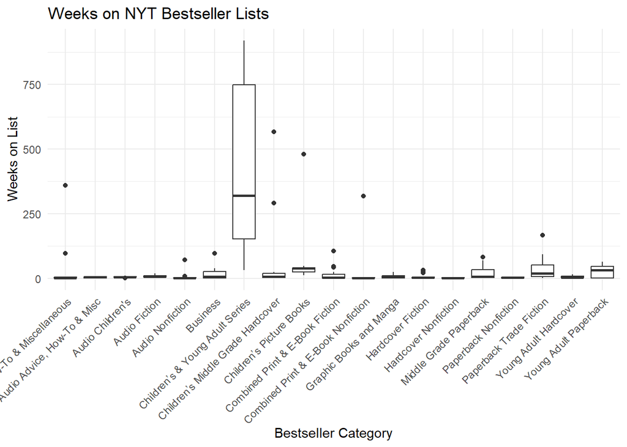

```r
ggplot(books_df_overview,
       aes(x = List, y = Weeks_on_List)) +
  geom_boxplot() +
  labs(
    title = "Weeks on NYT Bestseller Lists",
    x = "Bestseller Category",
    y = "Weeks on List"
  ) +
  theme_minimal() +
  theme(axis.text.x = element_text(angle = 45, hjust = 1))
```

```r
#Looking at why Children's books have such a huge >750 weeks streak.
books_df_overview |>
  filter(List == "Children’s Middle Grade Hardcover") |>
  arrange(desc(Weeks_on_List)) |>
  select(Title, Weeks_on_List)
```

```
                                     Title Weeks_on_List
1                                   WONDER           566
2    THE COMPLETE COOKBOOK FOR YOUNG CHEFS           292
3                           WOMBAT WAITING            24
4                  KIKI'S DELIVERY SERVICE             9
5                   KIKI AND THE NEW MAGIC             9
6                            THE WILD ZONE             4
7                             BUILDING 903             4
8  GAME OF PETS: THE BOY WHO KNEW TOO MUCH             4
9           DRAGONBORN: THE TWILIGHT CHILD             1
10                                LICORICE             1
```

# Data Cleaning:

The API response was returned in JSON format, with book infomation stored in nested lists. I extracted the *books* portion of the response and created a function called return_tidy to extract the data I needed i.e. publisher, weeks_on_the_list, etc.  
I also used the sapply() function to iterate through each book and extract it’s rank, title, author, description, publisher, and number of weeks on the best seller list.  
I then used data.frame() to organize these extracted fields into a structured table with each row representing an individual books.

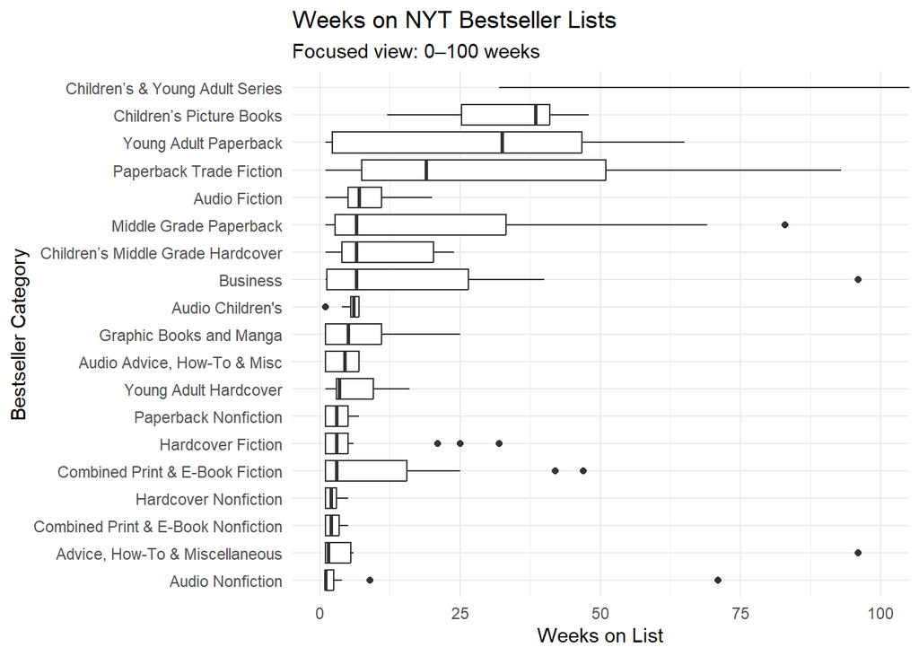

```r
ggplot(books_df_overview,
       aes(x = reorder(List, Weeks_on_List, FUN = median),
           y = Weeks_on_List)) +
  geom_boxplot() +
  coord_flip(ylim = c(0, 100)) +
  labs(
    title = "Weeks on NYT Bestseller Lists",
    subtitle = "Focused view: 0–100 weeks",
    x = "Bestseller Category",
    y = "Weeks on List"
  ) +
  theme_minimal()
```